# Exercise 2

Will

7/7/2020

This document fulfills the requirements for the week 2 project for Reproducible Research. First load the libraries we will need.

```r
library(dplyr)
library(lubridate)
```

Now read the data and replace the date as a character string with the date as a date. In question 8, I will need to separate weekdays from weekends. I’ll compute them here. I see no advantage in replacing the interval string with a date.

```r
wd=getwd()
setwd("C:/Users/wphut/Documents/R class/Reproduceable research/repdata_data_activity")
x<-read.csv("activity.csv", header=TRUE)
x$date<-ymd(x$date)
x$weekend <-ifelse(wday(x$date) %in% c(1,7), "weekend", "weekday")
```

We will need both data with and without missing values imputed.

**Question 6** asks for a strategy to replace the missing values. I will describe it here. Replace the missing values by the average of the times for that interval. If an observation was missing for one element in a day, it was missing for all observations in that day. Therefore, there is no advantage in taking other information from that day, only that interval. First, we compute the average for that interval across all days. Then we join it to the base data. We don’t need a by.x or by.y because there is only one matching field. Finally, we compute the imputed data as *steps* if it is not NA, and the interval average if it is.

```r
time_sum <- x %>% group_by(interval) %>%
      summarize(mean_steps = mean(steps, na.rm=TRUE))
added_time <- inner_join(x, time_sum, by=NULL)
added_time$imput_data<-ifelse(is.na(added_time$steps),
      added_time$mean_steps,
      added_time$steps)
```

```r
tot_steps <- added_time %>% group_by(date) %>%
      summarize(steps = sum(steps, na.rm=TRUE), imput_steps=sum(imput_data))
```

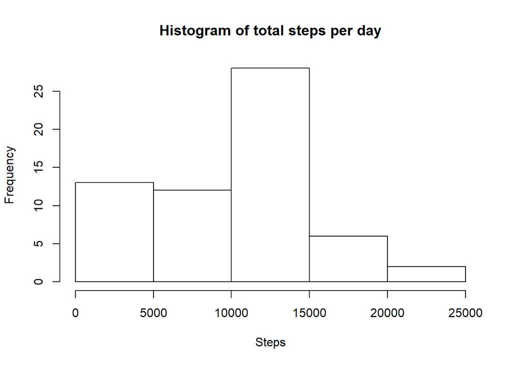

```r
hist(tot_steps$steps, xlab="Steps", main="Histogram of total steps per day")
```

Now we answer **question 3**, “Mean and median number of steps taken each day”.

```r
grand_total <- tot_steps %>% summarize(mean_steps = mean(steps, na.rm=TRUE),
                                    median_steps = median(steps, na.rm=TRUE))
grand_total
```

```
## # A tibble: 1 x 2
##   mean_steps median_steps
##        <dbl>        <int>
## 1      9354.        10395
```

**Question 4**. Time series plot of average steps taken each day. We computed the average steps per interval as part of imputing missing values and put it into the variable *time_sum*. We’ll reuse it here.

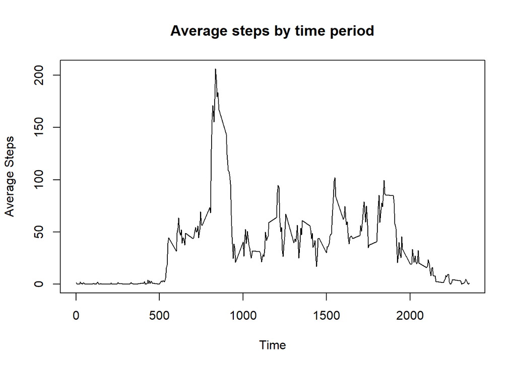

```r
plot(time_sum$interval, time_sum$mean_steps, xlab= "Time", ylab="Average Steps",
     main="Average steps by time period", type="l")
```

**Question 5** “The 5-minute interval that, on average, contains the maximum number of steps”.

```r
max_step<-filter(time_sum, mean_steps==max(time_sum$mean_steps))
max_step[1]
```

```
## # A tibble: 1 x 1
##   interval
##      <int>
## 1      835
```

**Question 6** is answered above where I describe how to impute missing values.

**Question 7** “Histogram of the total number of steps taken each day after missing values are imputed”

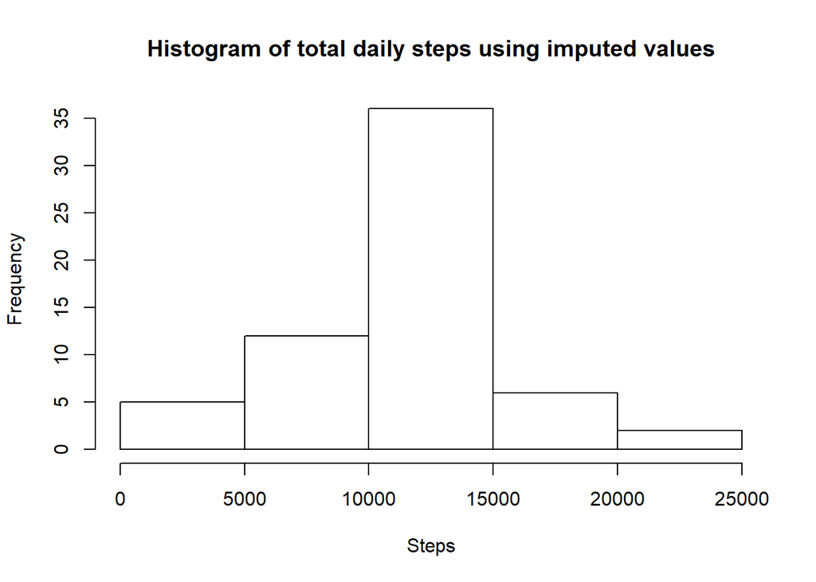

```r
hist(tot_steps$imput_steps, xlab="Steps", main="Histogram of total daily steps using imputed values")
```

**Question 8** “Panel plot comparing the average number of steps taken per 5-minute interval across weekdays and weekends” I interpreted this to mean we are averaging all the steps across all days in the weekday for a given 5 minute period. We are not summing the averages across all weekdays.

```r
wknd_avg <- x %>% group_by(interval, weekend) %>%
      summarize(time_mean = mean(steps, na.rm=TRUE))
```

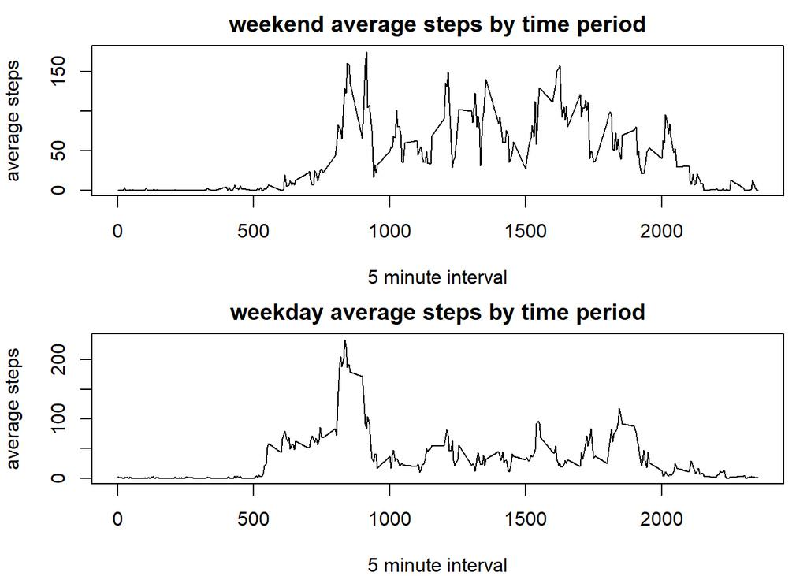

```r
wkday <- filter(wknd_avg, weekend=="weekday")
wknd<-filter(wknd_avg, weekend=="weekend")
par(mfrow = c(2, 1), mar = c(4, 4, 2, 1))
plot(wknd$interval, wknd$time_mean, type="l",
     xlab="5 minute interval", ylab="average steps",
     main="weekend average steps by time period")
plot(wkday$interval, wkday$time_mean, type="l",
     xlab="5 minute interval", ylab="average steps",
     main="weekday average steps by time period")
```

There is a noticeable difference in the pattern of weekday and weekend steps.